# Final Project Analysis Code and Final Report

**Project Title:** Never-use of long acting reversible contraception (LARC) among U.S. women aged 15-49 years

**Student Name:** Payal Chakraborty

## Introduction

Long-acting reversible contraception (LARC) is a class of birth control method that provides long lasting pregnancy prevention. There are two types of LARC methods, the intrauterine device (IUD) and the implant. The IUD gets inserted into the uterus, and the implant gets inserted into the skin of the upper arm. The methods are effective at preventing pregnancy because they remove the user error component of birth control, which other methods do not have: for example, for the birth control pill, the user has to remember to take it every day at the same time.

The disconnect between effectiveness and use may be explained by the various barriers individuals may face in obtaining LARC. Cost and insurance coverage is a major barrier in LARC uptake. Although the 2010 Affordable Care Act should have removed some of these cost and insurance barriers, there have been challenges made to the contraception mandate [4] and people may not be aware that LARC is available at no cost to them [5]. Since using LARC requires a physician office visit for insertion, scheduling and getting an appointment is a barrier for many people [6]. Additionally lack of knowledge and unfavorable attitudes may be a barrier to use; for example, many people hold misconceptions about LARC, and many are uncomfortable with the idea of newer methods [7], or having an object in the body. Also, many providers themselves lack about knowledge about LARC, and some hold incorrect beliefs that LARC is inappropriate for some women, and not others [8-12].

Reproductive coercion, especially targeting women of color, is also a huge problem, and can be a significant barrier to LARC uptake [13,14]. Reproductive coercion is rooted in the history in the US. In the 20th century, the US had forced sterilization programs targeting the poor, the disabled, criminals, and people of color. Nowadays, since LARC requires a physician for insertion and removal, sometimes physicians have refused to remove LARC because of their beliefs about whether their patients should be able to reproduce [15], undermining patient autonomy. Experiences like this deter many people from trying LARC in fear of not being able to get it removed, even if it could potentially benefit them.

Among users who willfully use LARC, the method has shown to have high efficacy, benefits, and acceptability. Anyone who wants LARC, should be able to use it. This project falls under the overarching goal of increasing accessibility of LARC for those who would most benefit from it and want it. The specific objectives of this project are explained in the next section.

**References**

1. Kavanaugh ML, Jerman J. Contraceptive method use in the United States: trends and characteristics between 2008, 2012 and 2014. Contraception 2018;97:14–21. https://doi.org/10.1016/j.contraception.2017.10.003.
2. Kavanaugh ML, Jerman J, Finer LB. Changes in use of long-acting reversible contraceptive methods among U.S. women. Obstet Gynecol 2015;126:917–27. https://doi.org/10.1097/AOG.0000000000001094.
3. Mosher WD, Jones J. Use of contraception in the United States: 1982-2008. Hyattsville, Md: U.S. Dept. of Health and Human Services, Centers for Disease Control and Prevention, National Center for Health Statistics; 2010.
4. Hall KS, Kottke M, Dalton VK, Hogue CR. Ongoing Implementation Challenges to the Patient Protection and Affordable Care Act’s Contraceptive Mandate. Am J Prev Med 2017;52:667–70. https://doi.org/10.1016/j.amepre.2016.10.014.
5. Rangel CB. Patient Protection and Affordable Care Act. 2009.
6. Serpico JJ, Ricks JM, Smooth WG, Romanos C, Brook DL, Gallo MF. Access to single-visit IUD insertion at obstetrician-gynecology practices in Ohio: an audit study. Contraception 2020. https://doi.org/10.1016/j.contraception.2020.05.007.
7. Politi MC, Estlund A, Milne A, Buckel CM, Peipert JF, Madden T. Barriers and facilitators to implementing a patient-centered model of contraceptive provision in community health centers. Contraception and Reproductive Medicine 2016;1:21.
8. Norris AH, Pritt NM, Berlan ED. Can pediatricians provide long-acting reversible contraception? J Pediatr Adolesc Gynecol 2019;32:39–43. https://doi.org/10.1016/j.jpag.2018.09.008.
9. Foster DG, Barar R, Gould H, Gomez I, Nguyen D, Biggs MA. Projections and opinions from 100 experts in long-acting reversible contraception. Contraception 2015;92:543–52. https://doi.org/10.1016/j.contraception.2015.10.003.
10. Tyler CP, Whiteman MK, Zapata LB, Curtis KM, Hillis SD, Marchbanks PA. Health care provider attitudes and practices related to intrauterine devices for nulliparous women. Obstet Gynecol 2012;119:762–71. https://doi.org/10.1097/AOG.0b013e31824aca39.
11. Harper CC, Henderson JT, Raine TR, Goodman S, Darney PD, Thompson KM, et al. Evidence-based IUD Practice: Family Physicians and Obstetrician-Gynecologists. Fam Med 2012;44:637–45.
12. Madden T, Allsworth JE, Hladky KJ, Secura GM, Peipert JF. Intrauterine contraception in Saint Louis: A Survey of Obstetrician and Gynecologists’ knowledge and attitudes. Contraception 2010;81:112. https://doi.org/10.1016/j.contraception.2009.08.002.
13. Gomez AM, Fuentes L, Allina A. Women or LARC first? Reproductive autonomy and the promotion of long‐acting reversible contraceptive methods. Perspectives on Sexual and Reproductive Health 2014;46:171–5.
14. Guarding Against Coercion While Ensuring Access: A Delicate Balance. Guttmacher Institute 2014. https://www.guttmacher.org/gpr/2014/09/guarding-against-coercion-while-ensuring-access-delicate-balance (accessed May 27, 2020).
15. Higgins JA. Celebration meets caution: LARC’s boons, potential busts, and the benefits of a reproductive justice approach. Contraception 2014;89:237–41.

## Objectives

Specifically, the objectives of this project are two-fold:

1. The first objective is to identify the most important features of ever LARC use among ever contraception users.
2. The second objective is to predict LARC use. This will help identify who might benefit most from LARC and from targeted outreach for LARC use. An indicator of lifetime use may be informative for targeting strategies for contraceptive counseling.

## Data Set: The National Survey of Family Growth (NSFG)

The National Survey of Family Growth (NSFG) is a national survey in the US. It is conducted by the US Centers for Disease Control and Prevention (CDC) in collaboration with other government agencies. The survey copies topics such as family life, marriage and divorce, pregnancy, infertility, use of contracpetion, and general and reproductive health. It is a publically available dataset and can be found on the US CDC website (https://www.cdc.gov/nchs/nsfg/index.htm).

The survey has been going on for many years, and has evolved over time. The first survey was conducted in 1973. Originally the survey was representative of women aged 15-44 in the U.S. In 2002, the survey expanded to include a sample of men that is independent from the women. In 2015, the survey expanded to ages 15-49 years. The response rate for recent years is about 69%, which is very high for a national survey. The administration of the survey is voluntary, and it is conducted via in-person interviews at participants' homes.

The NSFG is a widely used survey and is used by many different people: scholar and researchers, government agencies, and the media.

For this final project, I use the 2015-2017 survey. A total of 5,554 women participated in the 2015-2017 survey. The population of interest for this study is ever contraception users, so the final analytical sample consists of 4,904 women.

## Summary of Analysis Plan

**Primary Outcome:** The primary outcome of this analysis is ever use of LARC (yes/no). It is a binary variable and it is derived from ever use of IUD and ever use of implant. This variable has never been used in the NSFG data set.

**Primary Predictors:** There are several predictors of interest for this project. They fall under the following six categories: demographics (e.g. age, education, race, income, rural/urban residence, etc.), substance use (e.g. alcohol use, drug use), health care access (health insurance status, having a regular provider, place of health care seeking, etc.), relationship history (marital status, number of sexual partners, sex education, etc.), housing insecurity status (e.g. homelessness, inability to pay rent, etc.), and religious characteristics (religious affiliation, frequency of attending religious services now/past, etc.).

**Analysis Summary:** My primary model of interest is the neural network. I try using PCA and f-score method to reduce dimensions. About 23% of the sample has the outcome of interest, so I use class weights or resampling methods (synthetic minority oversampling technique [SMOTE] or undersampling) to deal with class imbalance. To tune the model, I adjust the number of input features, number of nodes, number of layers, droupout rate, learning rate, hidden layer activation functions, batch size, and number of epochs. To improve my prediction I try two enesmble learning methods, primarily ones that use the same model on different samples of the data, and then combine them. I use k-fold cross validation ensemble and bootstrap aggregation (bagging) ensemble, with logistic regression as the meta classifier for stacking the models. Finally, I compare my results with my final neural network model and more traditional methods, specifically logistic regression and a random forest classifier.

## Data Cleaning Code in Stata 16 (Before Importing Data to Python)

In this code, I import the data, create the outcome variable, and subset the variables that are needed for the analysis. I also clean all of the variables since response options such as "don't know" and "refused to answer" are coded differently for each individual variable. Therefore, I had to go through the variables one by one to recode these response options as missing.

```
clear

use "\\cifs-general.it.ohio-state.edu\cph-opn\Statewide Survey Data\Analysis Folders for Individual Projects\Chakraborty\larc_use\NSFG\2015_2017_FemRespData.dta"

svyset [pweight=WGT2015_2017], strata(SEST) psu(SECU)

*from IUD type variable
tab EVIUDTYP1, m
svy: tab EVIUDTYP1

tab EVIUDTYP2, m

tab EVIUDTYP1 EVIUDTYP2, m

gen ever_used_iud1 = 0
replace ever_used_iud1 = 1 if EVIUDTYP1 == 1 | EVIUDTYP1 == 2

tab ever_used_iud1 if EVERUSED == 1
svy, subpop(if EVERUSED == 1): tab ever_used_iud1

*from other method variable
gen everiud = 0
replace everiud = 1 if OTHRMETH01 == 19 | OTHRMETH02 == 19 | OTHRMETH03 == 19 | OTHRMETH04 == 19 | OTHRMETH05 == 19 | OTHRMETH06 == 19 | OTHRMETH07 == 19

gen everimplant = 0
replace everimplant = 1 if OTHRMETH01 == 9 | OTHRMETH02 == 9 | OTHRMETH03 == 9 | OTHRMETH04 == 9 | OTHRMETH05 == 9 | OTHRMETH06 == 9 | OTHRMETH07 == 9

gen everlarc = 0
replace everlarc = 1 if everiud == 1 | everimplant == 1

tab everiud if EVERUSED == 1
svy, subpop(if EVERUSED == 1): tab everiud

tab everimplant if EVERUSED == 1
svy, subpop(if EVERUSED == 1): tab everimplant

tab everlarc if EVERUSED == 1
svy, subpop(if EVERUSED == 1): tab everlarc


*Subset the data that is needed for analysis

keep CASEID WGT2015_2017 SEST SECU EVERUSED everiud everimplant everlarc AGE_R HISPANIC RACE ROSCNT EDUCAT BRNOUT RWRKST WRK12MOS TOTINCR POVERTY METRO MENARCHE RMARITAL EVRMARRY NUMPREGS PARITY LIFPRTNR AGEFSTSX EVRFORCD ATTRACT USUALCAR USLPLACE CURRCOV EVERFPC EVHPVTST GENWARTS SYPHILIS SAMESEX CHSUPPOR RELRAISD ATTNDNOW RELDLIFE ATTND14 RELCURR SEDNO SEDBC SEDSTD SEDABST SMK100 BINGE12 POT12 COC12 CRACK12 CRYSTMTH12 INJECT12 EVRINJECT NOBEDYR STAYREL EVSUSPEN WIDRAWAL RHYTHM SDAYCBDS TEMPSAFE PILL


*cleaning
label define yn 0 No 1 Yes

replace PILL = 0 if PILL == 5
replace PILL = . if PILL == 8

replace WIDRAWAL = 0 if WIDRAWAL == 5
replace WIDRAWAL = . if WIDRAWAL == 8 | WIDRAWAL == 9

replace RHYTHM = 0 if RHYTHM == 5
replace RHYTHM = . if RHYTHM == 8

replace SDAYCBDS = 0 if SDAYCBDS == 5
replace SDAYCBDS = . if SDAYCBDS == 8

replace TEMPSAFE = 0 if TEMPSAFE == 5
replace TEMPSAFE = . if TEMPSAFE == 8 | TEMPSAFE == 9


tab AGE_R, m
tab HISPANIC, m
replace HISPANIC = 0 if HISPANIC == 2
tab RACE, m
tab ROSCNT, m
tab EDUCAT, m

tab BRNOUT, m
replace BRNOUT = 0 if BRNOUT == 5
replace BRNOUT = . if BRNOUT == 9
label values BRNOUT yn

tab RWRKST, m
replace RWRKST = 0 if RWRKST == 5
label values RWRKST yn

tab WRK12MOS, m
replace WRK12MOS = . if WRK12MOS == 98 | WRK12MOS == 99

tab TOTINCR, m
tab POVERTY, m
tab METRO, m

tab MENARCHE, m
replace MENARCHE = 0 if MENARCHE == 96
replace MENARCHE = . if MENARCHE == 98
replace MENARCHE = . if MENARCHE == 99
label define men_lab 0 "PERIODS HAVE NOT YET BEGUN"
label values MENARCHE men_lab

tab RMARITAL, m
tab EVRMARRY, m
tab NUMPREGS, m
replace NUMPREGS = . if NUMPREGS == 98

tab PARITY, m
tab LIFPRTNR, m
tab AGEFSTSX, m
replace AGEFSTSX = . if AGEFSTSX == 98 | AGEFSTSX == 99

tab EVRFORCD, m
replace EVRFORCD = 0 if EVRFORCD == 5
replace EVRFORCD = . if EVRFORCD == 7 | EVRFORCD == 8 | EVRFORCD == 9
label values EVRFORCD yn

tab ATTRACT, m
replace ATTRACT = . if ATTRACT == 7 | ATTRACT == 8 | ATTRACT == 9

tab USUALCAR, m
replace USUALCAR = 0 if USUALCAR == 5
replace USUALCAR = . if USUALCAR == 9
label values USUALCAR yn

tab USLPLACE, m
replace USLPLACE = . if USLPLACE == 99

tab CURRCOV, m
replace CURRCOV = 0 if CURRCOV == 5
replace CURRCOV = . if CURRCOV == 9
label values CURRCOV yn

tab EVERFPC, m
replace EVERFPC = 0 if EVERFPC == 5
label values EVERFPC yn

tab EVHPVTST, m
replace EVHPVTST = 0 if EVHPVTST == 5
replace EVHPVTST = . if EVHPVTST == 9
label values EVHPVTST yn

tab GENWARTS, m
replace GENWARTS = 0 if GENWARTS == 5
replace GENWARTS = . if GENWARTS == 7 | GENWARTS == 8
label values GENWARTS yn


tab SYPHILIS, m
replace SYPHILIS = 0 if SYPHILIS == 5
replace SYPHILIS = . if SYPHILIS == 7 | SYPHILIS == 8 | SYPHILIS == 9
label values SYPHILIS yn

tab SAMESEX, m
gen SAMESEX_R = .
replace SAMESEX_R = 1 if SAMESEX == 1
replace SAMESEX_R = 2 if SAMESEX == 2
replace SAMESEX_R = 5 if SAMESEX == 4
replace SAMESEX_R = 4 if SAMESEX == 3
replace SAMESEX_R = 3 if SAMESEX == 5
label def sslbl 1 "Strongly agree" 2 "Agree" 3 "If R insists: Neither agree nor disagree" 4 "Disagree" 5 "Strongly disagree"
label val SAMESEX_R sslbl
drop SAMESEX

tab CHSUPPOR, m
gen CHSUPPOR_R = .
replace CHSUPPOR_R = 1 if CHSUPPOR == 1
replace CHSUPPOR_R = 2 if CHSUPPOR == 2
replace CHSUPPOR_R = 5 if CHSUPPOR == 4
replace CHSUPPOR_R = 4 if CHSUPPOR == 3
replace CHSUPPOR_R = 3 if CHSUPPOR == 5
label val CHSUPPOR_R sslbl
drop CHSUPPOR


tab RELRAISD, m
replace RELRAISD = . if RELRAISD == 9 | RELRAISD == 10


tab ATTNDNOW, m
replace ATTNDNOW = . if ATTNDNOW == 8 | ATTNDNOW == 9

tab RELDLIFE, m
replace RELDLIFE = . if RELDLIFE == 8 | RELDLIFE == 9
replace RELDLIFE = 3 if RELCURR == 1

tab ATTND14, m
replace ATTND14 = . if ATTND14 == 9

tab RELCURR, m
replace RELCURR = . if RELCURR == 9 | RELCURR == 10

tab SEDNO, m
replace SEDNO = 0 if SEDNO == 5
replace SEDNO = . if SEDNO == 9
label values SEDNO yn

tab SEDBC, m
replace SEDBC = 0 if SEDBC == 5
replace SEDBC = . if SEDBC == 9
label values SEDBC yn

tab SEDSTD, m
replace SEDSTD = 0 if SEDSTD == 5
replace SEDSTD = . if SEDSTD == 9
label values SEDSTD yn

tab SEDABST, m
replace SEDABST = 0 if SEDABST == 5
replace SEDABST = . if SEDABST == 9
label values SEDABST yn

tab SMK100, m
replace SMK100 = 0 if SMK100 == 5
replace SMK100 = . if SMK100 == 7 | SMK100 == 8
label values SMK100 yn

tab BINGE12, m
replace BINGE12 = . if BINGE12 == 7 | BINGE12 == 8 | BINGE12 == 9

tab POT12, m
replace POT12 = . if POT12 == 7 | POT12 == 8 | POT12 == 9

tab COC12, m
replace COC12 = . if COC12 == 7 | COC12 == 8 | COC12 == 9

tab CRACK12, m
replace CRACK12 = . if CRACK12 == 7 | CRACK12 == 8

tab CRYSTMTH12, m
replace CRYSTMTH12 = . if CRYSTMTH12 == 7 | CRYSTMTH12 == 8

tab INJECT12, m
replace INJECT12 = . if INJECT12 == 7 | INJECT12 == 8

tab EVRINJECT, m
replace EVRINJECT = . if EVRINJECT == 7 | EVRINJECT == 8 | EVRINJECT == 9
replace EVRINJECT = 0 if EVRINJECT == 5
label values EVRINJECT yn

tab NOBEDYR, m
replace NOBEDYR = . if NOBEDYR == 7 | NOBEDYR == 8 | NOBEDYR == 9
replace NOBEDYR = 0 if NOBEDYR == 5
label values NOBEDYR yn

tab STAYREL, m
replace STAYREL = . if STAYREL == 7 | STAYREL == 8 | STAYREL == 9
replace STAYREL = 0 if STAYREL == 5
label values STAYREL yn

tab EVSUSPEN, m
replace EVSUSPEN = . if EVSUSPEN == 7 | EVSUSPEN == 8 | EVSUSPEN == 9
replace EVSUSPEN = 0 if EVSUSPEN == 5
label values EVSUSPEN yn

order WGT2015_2017 SECU SEST everlarc, last

save "\\cifs-general.it.ohio-state.edu\cph-opn\Statewide Survey Data\Analysis Folders for Individual Projects\Chakraborty\larc_use\NSFG\2015_2017_FemRespData_clean.dta", replace

export delimited using "nsfg_clean", replace

export delimited using "\\cifs-general.it.ohio-state.edu\cph-opn\Statewide Survey Data\Analysis Folders for Individual Projects\Chakraborty\larc_use\NSFG\nsfg_clean_nolabel.csv", nolabel replace
```

## Import Libraries

```python
import numpy as np
import pandas as pd
import os

from sklearn.model_selection import train_test_split
from sklearn.pipeline import Pipeline
from sklearn.model_selection import KFold
from sklearn import metrics
from sklearn.metrics import log_loss
from sklearn.metrics import roc_curve
from sklearn.metrics import auc

import tensorflow as tf
from tensorflow import keras
import tensorflow_addons as tfa
import tensorflow.keras.backend as K
import tensorflow.keras.layers as L
import tensorflow.keras.models as M
import matplotlib.pyplot as plt

from sklearn.linear_model import LogisticRegression
from numpy import dstack
from numpy import mean
from numpy import std
from numpy import sqrt
from sklearn.metrics import accuracy_score
```

```python
!pwd
```

```
/users/PAS1475/payalc/BMI8050-2020/payal_project
```

## Load Dataset

```python
full_df = pd.read_csv('./nsfg_clean_nolabel1.csv')
full_df = full_df[full_df['EVERUSED'] == 1]
#full_df.head()
```

## Data Preprocessing

Most of the cleaning and recoding was done in Stata (code shown above). In this section, I impute the missing data (median for continuous variables and most frequent value for categorical variables). I also create a list of `non_properties` which will be enxcluded from the analysis because they are either variables that are not part of the analysis, have too many missing variables, or were removed to reduce dimensions from the f-score method (more shown below).

```python
datavars = list(full_df.columns.values)
continuous = ['AGE_R', 'ROSCNT', 'MENARCHE', 'NUMPREGS', 'AGEFSTSX', 'WRK12MOS', 'LIFPRTNR', 'POVERTY', 'PARITY']
cat_ord = ['SAMESEX_R', 'CHSUPPOR_R', 'TOTINCR', 'EDUCAT','ATTND14', 'ATTNDNOW']
cat_nom = ['EVRMARRY', 'PILL', 'WIDRAWAL', 'RHYTHM', 'SDAYCBDS', 'TEMPSAFE', 'SEDBC', 'SEDSTD', 'SEDABST', 'EVHPVTST', 'USUALCAR', 'USLPLACE', 'CURRCOV', 'BRNOUT', 'RELRAISD', 'RELCURR', 'RELDLIFE', 'RWRKST', 'NOBEDYR', 'STAYREL', 'EVSUSPEN', 'SMK100', 'ATTRACT', 'GENWARTS', 'SYPHILIS', 'EVRINJECT', 'RMARITAL', 'HISPANIC', 'RACE', 'METRO']
cat = ['SAMESEX_R', 'CHSUPPOR_R', 'TOTINCR', 'EDUCAT', 'ATTND14', 'ATTNDNOW', 'EVRMARRY', 'PILL', 'WIDRAWAL', 'RHYTHM', 'SDAYCBDS', 'TEMPSAFE', 'SEDNO', 'SEDBC', 'SEDSTD', 'SEDABST', 'EVHPVTST', 'USUALCAR', 'USLPLACE', 'CURRCOV', 'BRNOUT', 'RELRAISD', 'RELCURR', 'RELDLIFE', 'RWRKST', 'NOBEDYR', 'STAYREL', 'EVSUSPEN', 'SMK100', 'ATTRACT', 'GENWARTS', 'SYPHILIS', 'EVRINJECT', 'RMARITAL', 'HISPANIC', 'RACE', 'METRO']
cat_rem = ['everlarc','SAMESEX_R', 'CHSUPPOR_R', 'TOTINCR', 'EDUCAT', 'ATTND14', 'ATTNDNOW', 'EVRMARRY', 'PILL', 'WIDRAWAL', 'RHYTHM', 'SDAYCBDS', 'TEMPSAFE', 'SEDNO', 'SEDBC', 'SEDSTD', 'SEDABST', 'EVHPVTST', 'USUALCAR', 'USLPLACE', 'CURRCOV', 'BRNOUT', 'RELRAISD', 'RELCURR', 'RELDLIFE', 'RWRKST', 'NOBEDYR', 'STAYREL', 'EVSUSPEN', 'SMK100', 'ATTRACT', 'GENWARTS', 'SYPHILIS', 'EVRINJECT', 'RMARITAL', 'HISPANIC', 'RACE', 'METRO']

##### archive
#non_properties = ['CASEID', 'WGT2015_2017', 'SECU', 'SEST', 'BINGE12', 'POT12', 'COC12', 'CRACK12', 'CRYSTMTH12', 'INJECT12', 'EVERFPC', 'EVRFORCD', "EVERUSED", "everiud", "everimplant", 'GENWARTS', 'SYPHILIS', 'SEDNO', 'SEDBC', 'SEDSTD', 'SEDABST']
#non_properties = ['CASEID', 'WGT2015_2017', 'SECU', 'SEST', 'everlarc', 'ATTNDNOW', 'WRK12MOS']
##### initial
#non_properties = ['CASEID', 'WGT2015_2017', 'SECU', 'SEST', 'BINGE12', 'POT12', 'COC12', 'CRACK12', 'CRYSTMTH12', 'INJECT12', 'EVERFPC', 'EVRFORCD', "EVERUSED", "everiud", "everimplant"]
##### after first round
#non_properties = ['CASEID', 'WGT2015_2017', 'SECU', 'SEST', "EVERUSED", "everiud", "everimplant", 'BINGE12', 'POT12', 'COC12', 'CRACK12', 'CRYSTMTH12', 'INJECT12', 'EVERFPC', 'EVRFORCD', "MENARCHE", "BRNOUT"]
##### after second round
non_properties = ['CASEID', 'WGT2015_2017', 'SECU', 'SEST', "EVERUSED", "everiud", "everimplant", 'BINGE12', 'POT12', 'COC12', 'CRACK12', 'CRYSTMTH12', 'INJECT12', 'EVERFPC', 'EVRFORCD', "MENARCHE", "BRNOUT", 'RHYTHM']

for i in non_properties:
    datavars.remove(i)
    if i in continuous:
        continuous.remove(i)
    if i in cat_ord:
        cat_ord.remove(i)
    if i in cat:
        cat.remove(i)
    if i in cat_rem:
        cat_rem.remove(i)
print(datavars)
```

```
['AGE_R', 'ROSCNT', 'EVRMARRY', 'NUMPREGS', 'AGEFSTSX', 'SEDNO', 'SEDBC', 'SEDSTD', 'SEDABST', 'PILL', 'WIDRAWAL', 'SDAYCBDS', 'TEMPSAFE', 'EVHPVTST', 'USUALCAR', 'USLPLACE', 'CURRCOV', 'RELRAISD', 'ATTND14', 'RELCURR', 'RELDLIFE', 'ATTNDNOW', 'WRK12MOS', 'RWRKST', 'NOBEDYR', 'STAYREL', 'EVSUSPEN', …
```

Imputation to deal with missing data:

```python
# continuous
from sklearn.impute import SimpleImputer
imputer = SimpleImputer(missing_values=np.nan, strategy='median')
for c in continuous:
    full_df[[c]] = imputer.fit_transform(full_df[[c]])

#full_df.head()
```

```python
from sklearn.impute import SimpleImputer
# categorical
imputer_cat = SimpleImputer(missing_values=np.nan, strategy='most_frequent')
for v in cat_ord:
    full_df[[v]] = imputer_cat.fit_transform(full_df[[v]])

for v in cat_nom:
    full_df[[v]] = imputer_cat.fit_transform(full_df[[v]])
```

```python
full_df.head()
```

|  | CASEID | AGE_R | ROSCNT | EVRMARRY | MENARCHE | NUMPREGS | AGEFSTSX | SEDNO | SEDBC | SEDSTD | ... | POVERTY | TOTINCR | everiud | everimplant | SAMESEX_R | CHSUPPOR_R | WGT2015_2017 | SECU | SEST | everlarc |
| --- | --- | --- | --- | --- | --- | --- | --- | --- | --- | --- | --- | --- | --- | --- | --- | --- | --- | --- | --- | --- | --- |
| 1 | 70624 | 40.0 | 2.0 | 1 | 13.0 | 0.0 | 21.0 | NaN | 1.0 | 1.0 | ... | 423.0 | 13 | 0 | 0 | 5.0 | 5.0 | 18827.876206 | 3 | 331 | 0 |
| 2 | 70625 | 15.0 | 4.0 | 0 | 12.0 | 0.0 | 17.0 | 1.0 | 1.0 | 1.0 | ... | 57.0 | 5 | 0 | 0 | 2.0 | 4.0 | 3354.443830 | 2 | 366 | 0 |
| 3 | 70627 | 35.0 | 4.0 | 1 | 13.0 | 3.0 | 22.0 | NaN | 1.0 | 1.0 | ... | 500.0 | 15 | 1 | 0 | 2.0 | 2.0 | 19877.457610 | 3 | 322 | 1 |
| 4 | 70628 | 28.0 | 5.0 | 1 | 10.0 | 3.0 | 14.0 | NaN | 1.0 | 1.0 | ... | 189.0 | 12 | 1 | 0 | 2.0 | 2.0 | 4221.017695 | 2 | 366 | 1 |
| 5 | 70630 | 18.0 | 3.0 | 0 | 14.0 | 0.0 | 16.0 | 0.0 | 1.0 | 1.0 | ... | 33.0 | 2 | 0 | 1 | 5.0 | 1.0 | 2741.895741 | 1 | 364 | 1 |

5 rows × 62 columns

Notice that some variables still have missing. However, these variables were dropped from the analysis so it doesn't matter.

```python
#full_df.to_csv("imputed.csv")
```

One hot encoding for categorical data

```python
cat_df = full_df[cat_rem]
cat_df = pd.get_dummies(cat_df, columns=cat, drop_first=True)
cat_df = cat_df.set_index(full_df['CASEID'])
cat_df
```

| CASEID | everlarc | SAMESEX_R_2.0 | SAMESEX_R_3.0 | SAMESEX_R_4.0 | SAMESEX_R_5.0 | CHSUPPOR_R_2.0 | CHSUPPOR_R_3.0 | CHSUPPOR_R_4.0 | CHSUPPOR_R_5.0 | TOTINCR_2 | ... | RMARITAL_2 | RMARITAL_3 | RMARITAL_4 | RMARITAL_5 | RMARITAL_6 | HISPANIC_1 | RACE_2 | RACE_3 | METRO_2 | METRO_3 |
| --- | --- | --- | --- | --- | --- | --- | --- | --- | --- | --- | --- | --- | --- | --- | --- | --- | --- | --- | --- | --- | --- |
| 70624 | 0 | 0 | 0 | 0 | 1 | 0 | 0 | 0 | 1 | 0 | ... | 0 | 0 | 1 | 0 | 0 | 0 | 0 | 1 | 1 | 0 |
| 70625 | 0 | 1 | 0 | 0 | 0 | 0 | 0 | 1 | 0 | 0 | ... | 0 | 0 | 0 | 0 | 1 | 0 | 0 | 0 | 0 | 0 |
| 70627 | 1 | 1 | 0 | 0 | 0 | 1 | 0 | 0 | 0 | 0 | ... | 0 | 0 | 0 | 0 | 0 | 0 | 1 | 0 | 0 | 0 |
| 70628 | 1 | 1 | 0 | 0 | 0 | 1 | 0 | 0 | 0 | 0 | ... | 0 | 0 | 0 | 0 | 0 | 0 | 0 | 0 | 0 | 0 |
| 70630 | 1 | 0 | 0 | 0 | 1 | 0 | 0 | 0 | 0 | 1 | ... | 0 | 0 | 0 | 0 | 1 | 1 | 0 | 1 | 0 | 0 |
| ... | ... | ... | ... | ... | ... | ... | ... | ... | ... | ... | ... | ... | ... | ... | ... | ... | ... | ... | ... | ... | ... |
| 80704 | 0 | 0 | 0 | 0 | 0 | 1 | 0 | 0 | 0 | 0 | ... | 0 | 0 | 0 | 0 | 0 | 0 | 1 | 0 | 1 | 0 |
| 80705 | 0 | 0 | 0 | 0 | 1 | 0 | 0 | 0 | 0 | 0 | ... | 0 | 0 | 0 | 0 | 0 | 0 | 1 | 0 | 0 | 1 |
| 80710 | 0 | 0 | 0 | 0 | 0 | 0 | 0 | 0 | 0 | 0 | ... | 0 | 0 | 0 | 0 | 1 | 0 | 1 | 0 | 1 | 0 |
| 80712 | 0 | 1 | 0 | 0 | 0 | 0 | 0 | 1 | 0 | 0 | ... | 0 | 0 | 0 | 0 | 0 | 0 | 1 | 0 | 1 | 0 |
| 80715 | 0 | 0 | 0 | 0 | 0 | 0 | 0 | 0 | 0 | 0 | ... | 0 | 0 | 0 | 0 | 0 | 0 | 1 | 0 | 0 | 0 |

4904 rows × 107 columns

Scale continuous variables using min-max scaling

```python
from sklearn.preprocessing import MinMaxScaler
continuous_df = full_df[continuous]
scaler = MinMaxScaler(feature_range=(0,1))
scaler.fit(continuous_df)
normalized = scaler.transform(continuous_df)
normalized

df = pd.DataFrame(data=normalized, index=full_df['CASEID'], columns=[continuous], dtype=float)
#df.reset_index(inplace=True)
#pd.to_numeric(df['CASEID'])
df
```

| CASEID | AGE_R | ROSCNT | NUMPREGS | AGEFSTSX | WRK12MOS | LIFPRTNR | POVERTY | PARITY |
| --- | --- | --- | --- | --- | --- | --- | --- | --- |
| 70624 | 0.714286 | 0.142857 | 0.00 | 0.421053 | 0.416667 | 0.10 | 0.844444 | 0.000000 |
| 70625 | 0.000000 | 0.428571 | 0.00 | 0.315789 | 0.000000 | 0.00 | 0.105051 | 0.000000 |
| 70627 | 0.571429 | 0.428571 | 0.15 | 0.447368 | 1.000000 | 0.06 | 1.000000 | 0.142857 |
| 70628 | 0.371429 | 0.571429 | 0.15 | 0.236842 | 1.000000 | 0.08 | 0.371717 | 0.214286 |
| 70630 | 0.085714 | 0.285714 | 0.00 | 0.289474 | 0.166667 | 0.04 | 0.056566 | 0.000000 |
| ... | ... | ... | ... | ... | ... | ... | ... | ... |
| 80704 | 0.714286 | 0.142857 | 0.00 | 0.368421 | 1.000000 | 0.12 | 1.000000 | 0.000000 |
| 80705 | 0.771429 | 0.142857 | 0.10 | 0.289474 | 1.000000 | 0.06 | 0.402020 | 0.142857 |
| 80710 | 0.000000 | 0.428571 | 0.00 | 0.236842 | 0.083333 | 0.04 | 0.448485 | 0.000000 |
| 80712 | 0.828571 | 0.142857 | 0.40 | 0.131579 | 0.083333 | 0.12 | 0.458586 | 0.428571 |
| 80715 | 0.514286 | 0.142857 | 0.05 | 0.289474 | 1.000000 | 0.50 | 1.000000 | 0.000000 |

4904 rows × 8 columns

```python
FINAL=cat_df.join(df)
FINAL
FINAL.rename(columns=''.join, inplace=True)
FINAL.reset_index(inplace=True)
FINAL
final_df=FINAL.drop(['CASEID'], axis=1)
final_df
```

|  | everlarc | SAMESEX_R_2.0 | SAMESEX_R_3.0 | SAMESEX_R_4.0 | SAMESEX_R_5.0 | CHSUPPOR_R_2.0 | CHSUPPOR_R_3.0 | CHSUPPOR_R_4.0 | CHSUPPOR_R_5.0 | TOTINCR_2 | ... | METRO_2 | METRO_3 | AGE_R | ROSCNT | NUMPREGS | AGEFSTSX | WRK12MOS | LIFPRTNR | POVERTY | PARITY |
| --- | --- | --- | --- | --- | --- | --- | --- | --- | --- | --- | --- | --- | --- | --- | --- | --- | --- | --- | --- | --- | --- |
| 0 | 0 | 0 | 0 | 0 | 1 | 0 | 0 | 0 | 1 | 0 | ... | 1 | 0 | 0.714286 | 0.142857 | 0.00 | 0.421053 | 0.416667 | 0.10 | 0.844444 | 0.000000 |
| 1 | 0 | 1 | 0 | 0 | 0 | 0 | 0 | 1 | 0 | 0 | ... | 0 | 0 | 0.000000 | 0.428571 | 0.00 | 0.315789 | 0.000000 | 0.00 | 0.105051 | 0.000000 |
| 2 | 1 | 1 | 0 | 0 | 0 | 1 | 0 | 0 | 0 | 0 | ... | 0 | 0 | 0.571429 | 0.428571 | 0.15 | 0.447368 | 1.000000 | 0.06 | 1.000000 | 0.142857 |
| 3 | 1 | 1 | 0 | 0 | 0 | 1 | 0 | 0 | 0 | 0 | ... | 0 | 0 | 0.371429 | 0.571429 | 0.15 | 0.236842 | 1.000000 | 0.08 | 0.371717 | 0.214286 |
| 4 | 1 | 0 | 0 | 0 | 1 | 0 | 0 | 0 | 0 | 1 | ... | 0 | 0 | 0.085714 | 0.285714 | 0.00 | 0.289474 | 0.166667 | 0.04 | 0.056566 | 0.000000 |
| ... | ... | ... | ... | ... | ... | ... | ... | ... | ... | ... | ... | ... | ... | ... | ... | ... | ... | ... | ... | ... | ... |
| 4899 | 0 | 0 | 0 | 0 | 0 | 1 | 0 | 0 | 0 | 0 | ... | 1 | 0 | 0.714286 | 0.142857 | 0.00 | 0.368421 | 1.000000 | 0.12 | 1.000000 | 0.000000 |
| 4900 | 0 | 0 | 0 | 0 | 1 | 0 | 0 | 0 | 0 | 0 | ... | 0 | 1 | 0.771429 | 0.142857 | 0.10 | 0.289474 | 1.000000 | 0.06 | 0.402020 | 0.142857 |
| 4901 | 0 | 0 | 0 | 0 | 0 | 0 | 0 | 0 | 0 | 0 | ... | 1 | 0 | 0.000000 | 0.428571 | 0.00 | 0.236842 | 0.083333 | 0.04 | 0.448485 | 0.000000 |
| 4902 | 0 | 1 | 0 | 0 | 0 | 0 | 0 | 1 | 0 | 0 | ... | 1 | 0 | 0.828571 | 0.142857 | 0.40 | 0.131579 | 0.083333 | 0.12 | 0.458586 | 0.428571 |
| 4903 | 0 | 0 | 0 | 0 | 0 | 0 | 0 | 0 | 0 | 0 | ... | 0 | 0 | 0.514286 | 0.142857 | 0.05 | 0.289474 | 1.000000 | 0.50 | 1.000000 | 0.000000 |

4904 rows × 115 columns

```python
#final_df.to_csv("clean.csv")
```

Split the outcome variable and predictor variables:

```python
properties = list(final_df.columns.values)
#print(properties)
properties.remove('everlarc')

X = final_df[properties]
y = final_df['everlarc']
```

PCA to reduce features

```python
#X = np.log(X + 1)
```

```python
from sklearn.decomposition import PCA
n_input_1 = 40
X_PCA = PCA(n_components = n_input_1).fit_transform(X)
##x_train_1 = MinMaxScaler().fit_transform(x_train_1)
```

Split the data in to training and testing sets:

```python
X_train, X_test, y_train, y_test = train_test_split(X, y, test_size=0.1, random_state=42)
X_PCA_train, X_PCA_test, y_PCA_train, y_PCA_test = train_test_split(X_PCA, y, test_size=0.1, random_state=42)
```

Create functions for resampling. Note that undersampling did not work as well as SMOTE sampling, so I have the function for undersampling here but I did not end up using it.

```python
from imblearn.over_sampling import SMOTE
def SMOTEsampling(X_train,Y_train):
    sm=SMOTE(random_state=42)
    X_train, Y_train = sm.fit_sample(X_train, Y_train)
    return X_train,Y_train
```

```python
X_PCA_train_SMOTE,y_PCA_train_SMOTE=SMOTEsampling(X_PCA_train,y_PCA_train)
X_train_SMOTE,y_train_SMOTE=SMOTEsampling(X_train,y_train)
```

```python
from imblearn.under_sampling import RandomUnderSampler
def downsampling(X_train,Y_train):
    rds = RandomUnderSampler(random_state=42)
    X_train, Y_train = rds.fit_resample(X_train, Y_train)
    return X_train,Y_train
```

```python
#X_PCA_train,y_PCA_train=downsampling(X_PCA_train,y_PCA_train)
```

Helper variables:

```python
N_FEATURES = X_train.shape[1]
print("Full data features:", N_FEATURES)
N_PCA_FEATURES = X_PCA_train.shape[1]
print("PCA reduced features:", N_PCA_FEATURES)
#N_FEATURES_lasso = X_red_train.shape[1]
SEED = 654321
def seed_everything(seed):
    np.random.seed(seed)
    os.environ['PYTHONHASHSEED'] = str(seed)
    tf.random.set_seed(seed)
```

```
Full data features: 114
PCA reduced features: 40
```

## Model

First, examine class imbalance, and create class weights

```python
neg, pos = np.bincount(full_df['everlarc'])
total = neg + pos
print('Examples:\n    Total: {}\n    Positive: {} ({:.2f}% of total)\n'.format(
    total, pos, 100 * pos / total))
weight_for_0 = (1 / neg)*(total)/2.0
weight_for_1 = (1 / pos)*(total)/2.0

class_weight = {0: weight_for_0, 1: weight_for_1}

print('Weight for class 0: {:.2f}'.format(weight_for_0))
print('Weight for class 1: {:.2f}'.format(weight_for_1))
```

```
Examples:
    Total: 4904
    Positive: 1139 (23.23% of total)

Weight for class 0: 0.65
Weight for class 1: 2.15
```

### Wide Model

First, I started with one layer, and all of my input features included. I tuned the drop out rate, learning rate, number of nodes, and elu vs. relu activation function. I tried many many of combinations of all of these things (not shown for the purposes of simplicity). I easily get overfitting, so I did not have too much options in adding nodes to improve the accuracy. Even though the below model uses all 114 features, I also tried using the PCA version of the data with reduced features. Any reduction of features reduced the accuracy of this model, besides the two variables I removed using the f-score method (below). Thus, the following model is the final model I chose for the best wide model.

```python
seed_everything(SEED)
def create_model():
    # create model
    model = tf.keras.Sequential([
    tf.keras.layers.Input(N_FEATURES),
    tf.keras.layers.BatchNormalization(),
    tf.keras.layers.Dropout(0.1),
    tfa.layers.WeightNormalization(tf.keras.layers.Dense(80, activation='relu')),
    tf.keras.layers.BatchNormalization(),
    tf.keras.layers.Dropout(0.1),
    tfa.layers.WeightNormalization(tf.keras.layers.Dense(1, activation="sigmoid"))
    ])
    # Compile model
    model.compile(loss='binary_crossentropy', optimizer=tf.keras.optimizers.Adam(learning_rate = 0.0001), metrics=['accuracy'])
    return model

model = create_model()
```

```python
history= model.fit(X_train, y_train, epochs=10, batch_size=30,class_weight=class_weight, verbose=1, validation_split=0.2)

test_loss, test_acc = model.evaluate(X_test, y_test)
print('Test accuracy:', test_acc)
```

```
Test accuracy: 0.5987780094146729
```

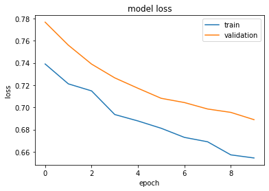

```python
plt.figure()
plt.plot(history.history['loss'])
plt.plot(history.history['val_loss'])
plt.title('model loss')
plt.ylabel('loss')
plt.xlabel('epoch')
plt.legend(['train', 'validation'])
plt.show()
```

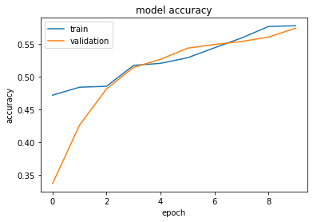

```python
plt.figure()
plt.plot(history.history['accuracy'])
plt.plot(history.history['val_accuracy'])
plt.title('model accuracy')
plt.ylabel('accuracy')
plt.xlabel('epoch')
plt.legend(['train', 'validation'])
plt.show()
```

I also tried the following wide model with PCA to reduce features, and various combinations (i.e. changing elu vs. relu, dropout rate, nodes, etc.). This did not work well.

```python
seed_everything(SEED)
def create_model_nf():
    # create model
    model = tf.keras.Sequential([
    tf.keras.layers.Input(N_PCA_FEATURES),
    tf.keras.layers.BatchNormalization(),
    #tf.keras.layers.Dropout(0.1),
    tfa.layers.WeightNormalization(tf.keras.layers.Dense(16, activation='elu')),
    tf.keras.layers.BatchNormalization(),
    tf.keras.layers.Dropout(0.2),
    tfa.layers.WeightNormalization(tf.keras.layers.Dense(1, activation="sigmoid"))
    ])
    # Compile model
    model.compile(loss='binary_crossentropy', optimizer=tf.keras.optimizers.Adam(learning_rate = 0.0001), metrics=['accuracy'])
    return model

model_nf = create_model_nf()
```

```python
history_nf= model_nf.fit(X_PCA_train, y_PCA_train, epochs=10, batch_size=30,class_weight=class_weight, verbose=1, validation_split=0.2)

test_loss_nf, test_acc_nf = model_nf.evaluate(X_PCA_test, y_test)
print('Test accuracy:', test_acc_nf)
```

```
Test accuracy: 0.5091649889945984
```

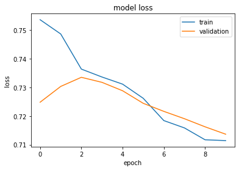

```python
plt.figure()
plt.plot(history_nf.history['loss'])
plt.plot(history_nf.history['val_loss'])
plt.title('model loss')
plt.ylabel('loss')
plt.xlabel('epoch')
plt.legend(['train', 'validation'])
plt.show()
```

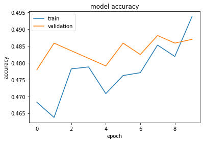

```python
plt.figure()
plt.plot(history_nf.history['accuracy'])
plt.plot(history_nf.history['val_accuracy'])
plt.title('model accuracy')
plt.ylabel('accuracy')
plt.xlabel('epoch')
plt.legend(['train', 'validation'])
plt.show()
```

### Deep Model

With the deep model, the elu activation function worked the best. When I add nodes or layers, I get slight overfitting. When I increase the dropout rate, to fix the overfitting, then accuracy goes down, lower than even the best wide model above. So then to deal with the overfitting, I introduced the PCA to reduce the number of input features. I first tried 20, then increased it to 32, and then I landed on 40. The model below is where I stopped in this cycle. For example, in the model before this model, my number of input features was 32. I had 2 hidden layers with 16 and 4 nodes; the dropout rate was 0.1; the number of epochs was 500, and the batch size was 200. This model gave an accuracy of 0.6008 withb slight overfitting. Then I increased the drop out to 0.12 and got an accuracy of 0.5926 and less overfitting. Then I increased the number of features to 40, and got an accuracy of 0.60896, with slight overftting again. Then when I increased the drop out to 0.2, the accuracy went back down to, but then reduced the overfitting problem by a bit, but it is still there. Since this was going in circles, I decided to stop at this model and try the next strategy.

Deep model with PCA to reduce features and class weights to deal with imbalance. Here you will see the slight overfitting problem. If you try to handle the overfitting with increasing the droupout, the accuracy decreases.

```python
seed_everything(SEED)
def create_deep_model():
    # create model
    model_deep = tf.keras.Sequential([
    tf.keras.layers.Input(N_PCA_FEATURES),
    tf.keras.layers.BatchNormalization(),
    tf.keras.layers.Dropout(0.2),
    tfa.layers.WeightNormalization(tf.keras.layers.Dense(16, activation='elu')),
    tf.keras.layers.BatchNormalization(),
    tf.keras.layers.Dropout(0.2),
    tfa.layers.WeightNormalization(tf.keras.layers.Dense(4, activation='elu')),
    tf.keras.layers.BatchNormalization(),
    tf.keras.layers.Dropout(0.2),
    tfa.layers.WeightNormalization(tf.keras.layers.Dense(1, activation="sigmoid"))
    ])
    # Compile model
    model_deep.compile(loss='binary_crossentropy', optimizer=tf.keras.optimizers.Adam(learning_rate = 0.0001), metrics=['accuracy'])
    return model_deep

model_deep = create_deep_model()
```

```python
history_deep= model_deep.fit(X_PCA_train, y_PCA_train, epochs=500, batch_size=200, verbose=1, class_weight=class_weight, validation_split=0.2)

test_loss_pca, test_acc_pca = model_deep.evaluate(X_PCA_test, y_PCA_test)
print('Test accuracy:', test_acc_pca)
```

```
Test accuracy: 0.5845214128494263
```

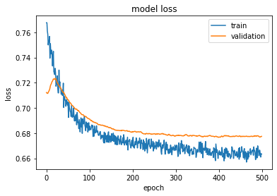

```python
plt.figure()
plt.plot(history_deep.history['loss'])
plt.plot(history_deep.history['val_loss'])
plt.title('model loss')
plt.ylabel('loss')
plt.xlabel('epoch')
plt.legend(['train', 'validation'])
plt.show()
```

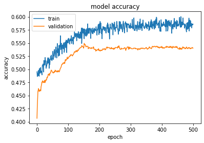

```python
plt.figure()
plt.plot(history_deep.history['accuracy'])
plt.plot(history_deep.history['val_accuracy'])
plt.title('model accuracy')
plt.ylabel('accuracy')
plt.xlabel('epoch')
plt.legend(['train', 'validation'])
plt.show()
```

```python
seed_everything(SEED)
def create_deep_model():
    # create model
    model_deep = tf.keras.Sequential([
    tf.keras.layers.Input(N_FEATURES),
    tf.keras.layers.BatchNormalization(),
    tf.keras.layers.Dropout(0.12),
    tfa.layers.WeightNormalization(tf.keras.layers.Dense(64, activation='elu')),
    tf.keras.layers.BatchNormalization(),
    tf.keras.layers.Dropout(0.12),
    tfa.layers.WeightNormalization(tf.keras.layers.Dense(32, activation='elu')),
    tf.keras.layers.BatchNormalization(),
    tf.keras.layers.Dropout(0.12),
    tfa.layers.WeightNormalization(tf.keras.layers.Dense(16, activation='elu')),
    tf.keras.layers.BatchNormalization(),
    tf.keras.layers.Dropout(0.12),
    #tfa.layers.WeightNormalization(tf.keras.layers.Dense(4, activation='elu')),
    #tf.keras.layers.BatchNormalization(),
    #tf.keras.layers.Dropout(0.12),
    tfa.layers.WeightNormalization(tf.keras.layers.Dense(1, activation="sigmoid"))
    ])
    # Compile model
    model_deep.compile(loss='binary_crossentropy', optimizer=tf.keras.optimizers.Adam(learning_rate = 0.0001), metrics=['accuracy'])
    return model_deep

model_deep = create_deep_model()
```

```python
history_deep= model_deep.fit(X_train_SMOTE, y_train_SMOTE, epochs=500, batch_size=200, verbose=1, validation_split=0.2)

test_loss_ds, test_acc_ds = model_deep.evaluate(X_test, y_test)
print('Test accuracy:', test_acc_ds)
```

```
Test accuracy: 0.7250509262084961
```

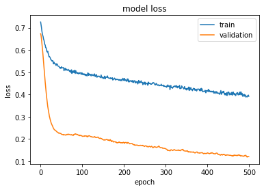

```python
plt.figure()
plt.plot(history_deep.history['loss'])
plt.plot(history_deep.history['val_loss'])
plt.title('model loss')
plt.ylabel('loss')
plt.xlabel('epoch')
plt.legend(['train', 'validation'])
plt.show()
```

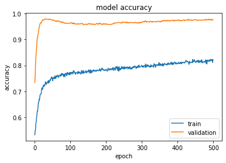

```python
plt.figure()
plt.plot(history_deep.history['accuracy'])
plt.plot(history_deep.history['val_accuracy'])
plt.title('model accuracy')
plt.ylabel('accuracy')
plt.xlabel('epoch')
plt.legend(['train', 'validation'])
plt.show()
```

### Reduce Features to Prevent Overfitting

Earlier in the code, I conducted PCA to reduce features to try to prevent overfitting. I also used the f-score method to more methodically see if any features were predicting particularly poorly which could be removed.

```python
from sklearn.feature_selection import SelectKBest
from sklearn.feature_selection import f_classif

selector = SelectKBest(f_classif, k=10)
selected_features = selector.fit_transform(X_train, y_train)
```

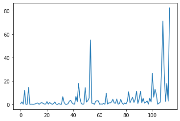

```python
plt.figure()
plt.plot(selector.scores_)
```

```python
# Best scores
f_score_indexes = (-selector.scores_).argsort()
f_score_indexes
```

```
array([113, 108,  53, 107, 109, 100, 111,  44,   6,  49, 102,   3,  88,
        91,  82,  65, 103,  42,  32, 101,  85,  45,  52,  98,  93,  90,
        73,  70,  87,  76,  84,  38,  51,  58,  96,  59, 112,  37,  81,
        57, 110,  20,  43,  99,   1,  69,  26,  50, 106,  95,  22,  86,
        33,  16,  92,  39,  83,  67,  77,  68,  71,  79,  13,  94,  54,
        15,  72, 105,  12,  63,  17,  89,  55,  75,  46,  23,  29,  25,
        36,   0,  80,  11,  61,  40,  48,  18,  19,  66,  97,  41,   8,
        30,  27,  21,  47, 104,   2,  62,   9,  60,   4,  34,  10,  74,
        31,   5,   7,  78,  35,  24,  28,  14,  56,  64])
```

Check lowest scores

```python
for i in f_score_indexes:
    print(X_train.columns[i])
```

```
PARITY
NUMPREGS
EVHPVTST_1.0
ROSCNT
AGEFSTSX
RMARITAL_6
LIFPRTNR
EVRMARRY_1
CHSUPPOR_R_4.0
SEDNO_1.0
RACE_2
SAMESEX_R_5.0
ATTRACT_2.0
ATTRACT_5.0
RELDLIFE_3.0
USLPLACE_20.0
RACE_3
ATTNDNOW_6.0
ATTND14_2.0
HISPANIC_1
STAYREL_1.0
PILL_1.0
SEDABST_1.0
RMARITAL_4
GENWARTS_1.0
ATTRACT_4.0
RELRAISD_8.0
RELRAISD_5.0
SMK100_1.0
RELCURR_4.0
NOBEDYR_1.0
ATTNDNOW_2.0
SEDSTD_1.0
USLPLACE_5.0
RMARITAL_2
USLPLACE_6.0
POVERTY
ATTND14_7.0
RELDLIFE_2.0
USLPLACE_4.0
```

[output cut: 59 more lines]

```
USLPLACE_7.0
CHSUPPOR_R_2.0
ATTND14_4.0
TOTINCR_4
RELCURR_2.0
EDUCAT_19
CHSUPPOR_R_3.0
CHSUPPOR_R_5.0
RELCURR_6.0
ATTND14_5.0
EDUCAT_12
EDUCAT_16
TOTINCR_8
USLPLACE_3.0
USLPLACE_11.0
```

Here, we cannot remove variables such as USLPLACE_11.0 because this is part of a variable where some levels predict decently well. In the first pass, we can remove `MENARCHE` and `BRNOUT`.

**Important Note: Careful removal of features using f-score method worked better than batch removal of features using PCA.**

### Better to go deeper or wider?

I have tried two strategies for building a neural network: getting the best wide neural network and getting the best deep neural network. The best wide network has one hidden layer (with relu activation function) with 80 notes, with class weights to deal with class imbalance. The best deep network has 64, 32, and 16 hidden layers (with elu activation function), and uses SMOTE resampling to deal with class imbalance. The best wide model achieves and accuracy of about 60% while the best deep layer achieves an accuracy of about 73%. However, the best wide model has more balanced sensitivity and specificity, while the best deep model has high specificity and *very* low sensitivity (more details on the sensitivity and specificity shown in the next section). Thus, the wider model is the better model, since a more balanced sensitivity and specificity is more desirable for this research problem. I will try to later improve this model using ensemble learning.

## Evaluate Model

### For Best Wide Model

```python
# Evaluate the model
print("Evaluate the model on the test data")
results = model.evaluate(X_test, y_test, batch_size=30)
print("test loss, test acc:", results)

# Generate prediction probabilities
print("Generate predictions")
predictions = model.predict(X_test)
print("predictions shape:", predictions.shape)

# Convert prediction probabilities to 0/1
y_pred = []
for p in predictions:
    if float(p[0]) < 0.5:
        y_pred.append(0)
    if float(p[0]) >= 0.5:
        y_pred.append(1)
```

```
Evaluate the model on the test data
test loss, test acc: [0.6645393371582031, 0.5987780094146729]
Generate predictions
predictions shape: (491, 1)
```

```python
# create the confusion matrix
cm = metrics.confusion_matrix(y_test, y_pred)
# columns names
cm_df = pd.DataFrame(cm,
            columns = ['Predicted Negative', 'Predicted Positive'],
            index = ['Actual Negative', 'Actual Positive'])
cm_df
```

|  | Predicted Negative | Predicted Positive |
| --- | --- | --- |
| Actual Negative | 217 | 152 |
| Actual Positive | 45 | 77 |

```python
def confusion_metrics (conf_matrix):
    TP = conf_matrix[1][1]
    TN = conf_matrix[0][0]
    FP = conf_matrix[0][1]
    FN = conf_matrix[1][0]
    print('True Positives:', TP)
    print('True Negatives:', TN)
    print('False Positives:', FP)
    print('False Negatives:', FN)

    # accuracy
    conf_accuracy = (float (TP+TN) / float(TP + TN + FP + FN))

    # mis-classification
    conf_misclassification = 1- conf_accuracy

    # sensitivity (recall)
    conf_sensitivity = (TP / float(TP + FN))
    # specificity
    conf_specificity = (TN / float(TN + FP))

    # precision (PPV)
    conf_precision = (TP / float(TP + FP))

    # f_1 score
    conf_f1 = 2 * ((conf_precision * conf_sensitivity) / (conf_precision + conf_sensitivity))
    print('-'*20)
    print(f'Accuracy: {round(conf_accuracy,2)}')
    print(f'Mis-Classification: {round(conf_misclassification,2)}')
    print(f'Sensitivity (Recall): {round(conf_sensitivity,2)}')
    print(f'Specificity: {round(conf_specificity,2)}')
    print(f'Precision: {round(conf_precision,2)}')
    print(f'f_1 Score: {round(conf_f1,2)}')
```

```python
confusion_metrics(cm)
```

```
True Positives: 77
True Negatives: 217
False Positives: 152
False Negatives: 45
--------------------
Accuracy: 0.6
Mis-Classification: 0.4
Sensitivity (Recall): 0.63
Specificity: 0.59
Precision: 0.34
f_1 Score: 0.44
```

```python
y_pred_keras = model.predict(X_test).ravel()
fpr_keras, tpr_keras, thresholds_keras = roc_curve(y_test, y_pred_keras)
auc_keras = auc(fpr_keras, tpr_keras)
```

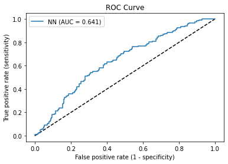

```python
plt.figure(1)
plt.plot([0, 1], [0, 1], 'k--')
plt.plot(fpr_keras, tpr_keras, label='NN (AUC = {:.3f})'.format(auc_keras))
plt.xlabel('False positive rate (1 - specificity)')
plt.ylabel('True positive rate (sensitivity)')
plt.title('ROC Curve')
plt.legend(loc='best')
plt.show()
```

This is the ROC curve for the best wide model. The AUC is 0.641.

```python
from sklearn.metrics import precision_recall_curve
from sklearn.metrics import f1_score
keras_precision, keras_recall, _ = precision_recall_curve(y_test, y_pred_keras)
f1_keras, auc_kerasf = f1_score(y_test, y_pred), auc(keras_recall, keras_precision)
```

```
NN: f1=0.439 auc=0.338
```

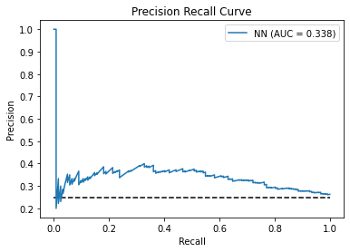

```python
print('NN: f1=%.3f auc=%.3f' % (f1_keras, auc_kerasf))
plt.figure(1)
no_skill = len(y_test[y_test==1]) / len(y_test)
plt.plot([0, 1], [no_skill, no_skill], 'k--')
plt.plot(keras_recall, keras_precision, label='NN (AUC = {:.3f})'.format(auc_kerasf))
plt.xlabel('Recall')
plt.ylabel('Precision')
plt.title('Precision Recall Curve')
plt.legend(loc='best')
plt.show()
```

This is the precision recall curve for the best wide model. The AUC is 0.338.

### Metrics for Best Deep Model

```python
results_deep = model_deep.evaluate(X_test, y_test)

print("Generate predictions")
predictions_deep = model_deep.predict(X_test)
print("predictions shape:", predictions_deep.shape)

# Convert prediction probabilities to 0/1
y_pred_deep = []
for pd in predictions_deep:
    if float(pd[0]) < 0.5:
        y_pred_deep.append(0)
    if float(pd[0]) >= 0.5:
        y_pred_deep.append(1)
```

```
Generate predictions
predictions shape: (491, 1)
```

```python
cm_deep = metrics.confusion_matrix(y_test, y_pred_deep)
confusion_metrics(cm_deep)
```

```
True Positives: 22
True Negatives: 334
False Positives: 35
False Negatives: 100
--------------------
Accuracy: 0.73
Mis-Classification: 0.27
Sensitivity (Recall): 0.18
Specificity: 0.91
Precision: 0.39
f_1 Score: 0.25
```

As you can see here, the sensitivity for the best deep model is 18% and the specificity is 91%. The sensitivity is very low. However the sensitivity for the best wide model is 63% and the specificity is 59%. This is much more balanced, so I will pick the best wide model, and see if the prediction of this model can be improved with the ensemble methods below.

## Try Ensemble Learning Methods

Source for applying ensemble methods: https://machinelearningmastery.com/how-to-create-a-random-split-cross-validation-and-bagging-ensemble-for-deep-learning-in-keras/

Source for stacking models: https://machinelearningmastery.com/stacking-ensemble-for-deep-learning-neural-networks/

In this section, I try two popular ensemble learning methods to see if these methods can improve the model performance as a proof of concept. Both methods involve training different samples of the dataset. The two methods that I try are (1) k-fold cross-validation and (2) bagging (or bootrstrap aggregation).

First, I re-specify the model:

```python
seed_everything(1234)
def evaluate_model(trainX, trainy, testX, testy):
    # define model
    model = tf.keras.Sequential([
    tf.keras.layers.Input(N_FEATURES),
    tf.keras.layers.BatchNormalization(),
    tf.keras.layers.Dropout(0.1),
    tfa.layers.WeightNormalization(tf.keras.layers.Dense(84, activation='relu')),
    tf.keras.layers.BatchNormalization(),
    tf.keras.layers.Dropout(0.1),
    tfa.layers.WeightNormalization(tf.keras.layers.Dense(1, activation="sigmoid"))
    ])
    model.compile(loss='binary_crossentropy', optimizer=tf.keras.optimizers.Adam(learning_rate = 0.0001), metrics=['binary_accuracy'])
    # fit model
    model.fit(trainX, trainy, epochs=10, batch_size=30, class_weight=class_weight, verbose=0)
    # evaluate the model
    _, test_acc = model.evaluate(testX, testy, verbose=0)
    return model, test_acc
```

Define functions that I will use the stack the models:

```python
def stacked_dataset(members, inputX):
    stackX = None
    for model in members:
        # make prediction
        yhat = model.predict(inputX, verbose=0)
        # stack predictions into [rows, members, probabilities]
        if stackX is None:
            stackX = yhat
        else:
            stackX = dstack((stackX, yhat))
    # flatten predictions to [rows, members x probabilities]
    stackX = stackX.reshape((stackX.shape[0], stackX.shape[1]*stackX.shape[2]))
    return stackX
```

```python
# fit a model based on the outputs from the ensemble members
def fit_stacked_model(members, inputX, inputy):
    # create dataset using ensemble
    stackedX = stacked_dataset(members, inputX)
    # fit standalone model
    model_s = LogisticRegression(class_weight=class_weight)
    model_s.fit(stackedX, inputy)
    return model_s
```

```python
def stacked_prediction(members, model, inputX):
    # create dataset using ensemble
    stackedX = stacked_dataset(members, inputX)
    # make a prediction
    yhat = model.predict(stackedX)
    yhat_prob = model.predict_proba(stackedX)
    return yhat, yhat_prob
```

### Bagging (Bootstrap Aggregation) Ensemble

The steps for the bagging method are similar. Here, I use the "resample" function from the sklearn package to coduct the bootstrap sampling.

```python
from sklearn.utils import resample
# multiple train-test splits
n_splits = 10
b_scores, b_members = list(), list()
for _ in range(n_splits):
    # select indexes
    ix = [i for i in range(len(X))]
    train_ix = resample(ix, replace=True, n_samples=2000, random_state=42)
    test_ix = [x for x in ix if x not in train_ix]
    # select data
    trainX, trainy = X.iloc[train_ix], y.iloc[train_ix]
    testX, testy = X.iloc[test_ix], y.iloc[test_ix]
    # evaluate model
    model, test_acc = evaluate_model(trainX, trainy, testX, testy)
    print('>%.3f' % test_acc)
    b_scores.append(test_acc)
    b_members.append(model)
```

```
>0.544
>0.543
>0.570
>0.558
>0.540
>0.533
>0.567
>0.526
>0.539
>0.562
```

Calculate expected performance if there is no meta classifier:

```python
print('Estimated Accuracy %.3f (%.3f)' % (mean(b_scores), std(b_scores)))
```

```
Estimated Accuracy 0.548 (0.014)
```

Stack model and get predictions:

```python
stacked_b_model = fit_stacked_model(b_members, trainX, trainy)
```

```python
b_yhat, b_yhat_prob = stacked_prediction(b_members, stacked_b_model, testX)
b_acc = accuracy_score(testy, b_yhat)
print('Stacked Test Accuracy: %.3f' % b_acc)
```

```
Stacked Test Accuracy: 0.619
```

```python
# create the confusion matrix
cm_stacked_b = metrics.confusion_matrix(testy, b_yhat)
cm_stacked_b
```

```
array([[1612,  885],
       [ 355,  401]])
```

```python
confusion_metrics(cm_stacked_b)
```

```
True Positives: 401
True Negatives: 1612
False Positives: 885
False Negatives: 355
--------------------
Accuracy: 0.62
Mis-Classification: 0.38
Sensitivity (Recall): 0.53
Specificity: 0.65
Precision: 0.31
f_1 Score: 0.39
```

Here, we get a slightly better accuracy, but the sensitivity has greatly decreased compared to the individual model.

### K-Fold Cross Validation Ensemble

Here, first I prepare the k-fold cross-validation configuration, and then estimate performance. Although k=10 is typical, I use k=5 since I don't have a big sample size.

```python
# prepare the k-fold cross-validation configuration
n_folds = 5
kfold = KFold(n_folds, random_state=42, shuffle=True)
# cross validation estimation of performance
kf_scores, kf_members = list(), list()
for train_ix, test_ix in kfold.split(X):
    # select samples
    trainX, trainy = X.iloc[train_ix], y.iloc[train_ix]
    testX, testy = X.iloc[test_ix], y.iloc[test_ix]
    # evaluate model
    model, test_acc = evaluate_model(trainX, trainy, testX, testy)
    print('>%.3f' % test_acc)
    kf_scores.append(test_acc)
    kf_members.append(model)
```

```
>0.584
>0.560
>0.579
>0.530
>0.580
```

Calculate estimated accuracy for simple average:

```python
print('Estimated Accuracy %.3f (%.3f)' % (mean(kf_scores), std(kf_scores)))
```

```
Estimated Accuracy 0.566 (0.020)
```

```python
stacked_k_model = fit_stacked_model(kf_members, testX, testy)
```

```python
kf_yhat, kf_yhat_prob = stacked_prediction(kf_members, stacked_k_model, testX)
kf_acc = accuracy_score(testy, kf_yhat)
print('Stacked Test Accuracy: %.3f' % kf_acc)
```

```
Stacked Test Accuracy: 0.661
```

```python
# create the confusion matrix
cm_stacked_k = metrics.confusion_matrix(testy, kf_yhat)
cm_stacked_k
```

```
array([[480, 267],
       [ 65, 168]])
```

```python
confusion_metrics(cm_stacked_k)
```

```
True Positives: 168
True Negatives: 480
False Positives: 267
False Negatives: 65
--------------------
Accuracy: 0.66
Mis-Classification: 0.34
Sensitivity (Recall): 0.72
Specificity: 0.64
Precision: 0.39
f_1 Score: 0.5
```

The k-fold cross-validation ensemble method leads to an improvement in accuracy, sensitivity and specificity compared to the individual model.

### Conclusion about ensemble learning results

The k-fold cross-validation ensemble worked best, and thus will be used as the final ensemble method.

**NOTE:** I also tried the ensemble methods on the deep models. For these models, both the K-fold cross validation and bagging ensembles performed worse than the individual model. The K-fold cross validation ensemble with the best wide model had the best metrics out of all of these models.

Now I will plot the ROC curve and the precision-recall curve, over the curve for the individual model so that we can compare.

```python
fpr_ens, tpr_ens, thresholds_ens = roc_curve(testy, kf_yhat_prob[:, 1])
auc_ens = auc(fpr_ens, tpr_ens)
```

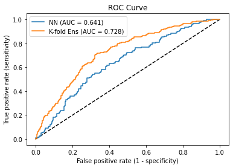

```python
plt.figure()
plt.plot([0, 1], [0, 1], 'k--')
plt.plot(fpr_keras, tpr_keras, label='NN (AUC = {:.3f})'.format(auc_keras))
plt.plot(fpr_ens, tpr_ens, label='K-fold Ens (AUC = {:.3f})'.format(auc_ens))
plt.xlabel('False positive rate (1 - specificity)')
plt.ylabel('True positive rate (sensitivity)')
plt.title('ROC Curve')
plt.legend(loc='best')
plt.show()
```

This ROC curve visually shows that the K-fold cross validation ensemble is better that the individual neural network model.

```python
ens_precision, ens_recall, ens_thresh = precision_recall_curve(testy, kf_yhat_prob[:, 1])
f1_ens, auc_ensf = f1_score(testy, kf_yhat), auc(ens_recall, ens_precision)
print('K-fold CV Ensemble: f1=%.3f auc=%.3f' % (f1_ens, auc_ensf))
```

```
K-fold CV Ensemble: f1=0.503 auc=0.429
```

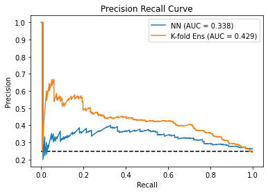

```python
plt.figure(1)
no_skill = len(y_test[y_test==1]) / len(y_test)
plt.plot([0, 1], [no_skill, no_skill], 'k--')
plt.plot(keras_recall, keras_precision, label='NN (AUC = {:.3f})'.format(auc_kerasf))
plt.plot(ens_recall, ens_precision, label='K-fold Ens (AUC = {:.3f})'.format(auc_ensf))
plt.xlabel('Recall')
plt.ylabel('Precision')
plt.title('Precision Recall Curve')
plt.legend(loc='best')
plt.show()
```

This precision-recall curve shows that the K-fold cross validation ensemble is much better than the individual neural network model.

## Comparison with other methods

### Logistic Regression

I also show the application of logisitc regression as a comparison with the neural network models.

```python
# Run model
logreg = LogisticRegression(class_weight=class_weight, max_iter=150)
logreg.fit(X_train, y_train)
# Get predictions
y_pred = logreg.predict(X_test)
# Calculating class probabilities
pred_proba = [i[1] for i in logreg.predict_proba(X_test)]
pred_df = pd.DataFrame({'true_values': y_test,
                        'pred_probs':pred_proba})

# Thresholds
thresholds = np.linspace(0, 1, 200)

# Calculate sensitivity. (True positive rate.)
def TPR(df, true_col, pred_prob_col, threshold):
    true_positive = df[(df[true_col] == 1) & (df[pred_prob_col] >= threshold)].shape[0]
    false_negative = df[(df[true_col] == 1) & (df[pred_prob_col] < threshold)].shape[0]
    return true_positive / (true_positive + false_negative)

# Calculate 1 - specificity. (False positive rate.)
def FPR(df, true_col, pred_prob_col, threshold):
    true_negative = df[(df[true_col] == 0) & (df[pred_prob_col] <= threshold)].shape[0]
    false_positive = df[(df[true_col] == 0) & (df[pred_prob_col] > threshold)].shape[0]
    return 1 - (true_negative / (true_negative + false_positive))

# Calculate sensitivity & 1-specificity for each threshold between 0 and 1.
tpr_values = [TPR(pred_df, 'true_values', 'pred_probs', prob) for prob in thresholds]
fpr_values = [FPR(pred_df, 'true_values', 'pred_probs', prob) for prob in thresholds]
```

```python
cm_lr = metrics.confusion_matrix(y_test, y_pred)
cm_lr_df = pd.DataFrame(cm_lr,
            columns = ['Predicted Negative', 'Predicted Positive'],
            index = ['Actual Negative', 'Actual Positive'])
cm_lr_df
```

|  | Predicted Negative | Predicted Positive |
| --- | --- | --- |
| Actual Negative | 240 | 129 |
| Actual Positive | 50 | 72 |

```python
confusion_metrics(cm_lr)
```

```
True Positives: 72
True Negatives: 240
False Positives: 129
False Negatives: 50
--------------------
Accuracy: 0.64
Mis-Classification: 0.36
Sensitivity (Recall): 0.59
Specificity: 0.65
Precision: 0.36
f_1 Score: 0.45
```

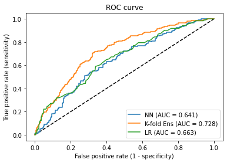

```python
auc_lg = auc(fpr_values, tpr_values)

plt.figure(2)
plt.plot([0, 1], [0, 1], 'k--')
plt.plot(fpr_keras, tpr_keras, label='NN (AUC = {:.3f})'.format(auc_keras))
plt.plot(fpr_ens, tpr_ens, label='K-fold Ens (AUC = {:.3f})'.format(auc_ens))
plt.plot(fpr_values, tpr_values, label='LR (AUC = {:.3f})'.format(auc_lg))
plt.xlabel('False positive rate (1 - specificity)')
plt.ylabel('True positive rate (sensitivity)')
plt.title('ROC curve')
plt.legend(loc='best')
plt.show()
```

```python
lr_precision, lr_recall, _ = precision_recall_curve(y_test, pred_proba)
f1_lr, auc_lrf = f1_score(y_test, y_pred), auc(lr_recall, lr_precision)
```

```
Logistic Regression (LR): f1=0.446 auc=0.393
```

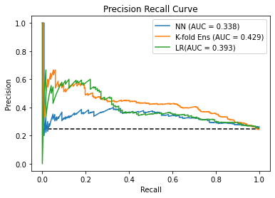

```python
print('Logistic Regression (LR): f1=%.3f auc=%.3f' % (f1_lr, auc_lrf))
plt.figure(1)
no_skill = len(y_test[y_test==1]) / len(y_test)
plt.plot([0, 1], [no_skill, no_skill], 'k--')
plt.plot(keras_recall, keras_precision, label='NN (AUC = {:.3f})'.format(auc_kerasf))
plt.plot(ens_recall, ens_precision, label='K-fold Ens (AUC = {:.3f})'.format(auc_ensf))
plt.plot(lr_recall, lr_precision, label='LR(AUC = {:.3f})'.format(auc_lrf))
plt.xlabel('Recall')
plt.ylabel('Precision')
plt.title('Precision Recall Curve')
plt.legend(loc='best')
plt.show()
```

### Random Forest Classifier

```python
from sklearn.ensemble import RandomForestClassifier
# Supervised transformation based on random forests
rf = RandomForestClassifier(max_depth=3, n_estimators=10, class_weight=class_weight)
rf.fit(X_train, y_train)

y_pred_rf = rf.predict_proba(X_test)[:, 1]
fpr_rf, tpr_rf, thresholds_rf = roc_curve(y_test, y_pred_rf)
auc_rf = auc(fpr_rf, tpr_rf)
```

```python
# Convert prediction probabilities to 0/1
y_pred_rf_final = []
for p in y_pred_rf:
    if float(p) < 0.5:
        y_pred_rf_final.append(0)
    if float(p) >= 0.5:
        y_pred_rf_final.append(1)
```

```python
cm_rf = metrics.confusion_matrix(y_test, y_pred_rf_final)
cm_rf_df = pd.DataFrame(cm_rf,
            columns = ['Predicted Negative', 'Predicted Positive'],
            index = ['Actual Negative', 'Actual Positive'])
cm_rf_df
```

|  | Predicted Negative | Predicted Positive |
| --- | --- | --- |
| Actual Negative | 227 | 142 |
| Actual Positive | 45 | 77 |

```python
confusion_metrics(cm_rf)
```

```
True Positives: 77
True Negatives: 227
False Positives: 142
False Negatives: 45
--------------------
Accuracy: 0.62
Mis-Classification: 0.38
Sensitivity (Recall): 0.63
Specificity: 0.62
Precision: 0.35
f_1 Score: 0.45
```

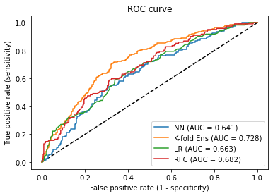

```python
plt.figure(3)
plt.plot([0, 1], [0, 1], 'k--')
plt.plot(fpr_keras, tpr_keras, label='NN (AUC = {:.3f})'.format(auc_keras))
plt.plot(fpr_ens, tpr_ens, label='K-fold Ens (AUC = {:.3f})'.format(auc_ens))
plt.plot(fpr_values, tpr_values, label='LR (AUC = {:.3f})'.format(auc_lg))
plt.plot(fpr_rf, tpr_rf, label='RFC (AUC = {:.3f})'.format(auc_rf))
plt.xlabel('False positive rate (1 - specificity)')
plt.ylabel('True positive rate (sensitivity)')
plt.title('ROC curve')
plt.legend(loc='best')
plt.show()
```

```python
rf_precision, rf_recall, _ = precision_recall_curve(y_test, y_pred_rf)
f1_rf, auc_rff = f1_score(y_test, y_pred_rf_final), auc(rf_recall, rf_precision)
print('Random Forest Classifier (RFC): f1=%.3f auc=%.3f' % (f1_rf, auc_rff))
```

```
Random Forest Classifier (RFC): f1=0.452 auc=0.429
```

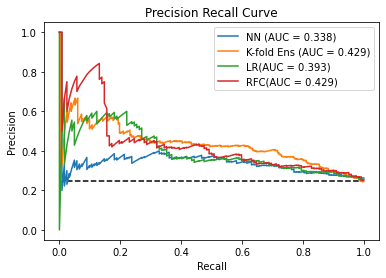

```python
plt.figure(1)
no_skill = len(y_test[y_test==1]) / len(y_test)
plt.plot([0, 1], [no_skill, no_skill], 'k--')
plt.plot(keras_recall, keras_precision, label='NN (AUC = {:.3f})'.format(auc_kerasf))
plt.plot(ens_recall, ens_precision, label='K-fold Ens (AUC = {:.3f})'.format(auc_ensf))
plt.plot(lr_recall, lr_precision, label='LR(AUC = {:.3f})'.format(auc_lrf))
plt.plot(rf_recall, rf_precision, label='RFC(AUC = {:.3f})'.format(auc_rff))
plt.xlabel('Recall')
plt.ylabel('Precision')
plt.title('Precision Recall Curve')
plt.legend(loc='best')
plt.show()
```

## Important Features of LARC Ever-Use

I use the individual neural network model to derive the most important features.

```python
from tensorflow.keras.wrappers.scikit_learn import KerasClassifier, KerasRegressor
import eli5
from eli5.sklearn import PermutationImportance

estimator = KerasRegressor(build_fn=create_model, validation_split = 0.2, batch_size=30, epochs=10, verbose=0)
estimator.fit(X_train,y_train)

perm = PermutationImportance(estimator, random_state=1).fit(X_train,y_train)
eli5.show_weights(perm, feature_names = X_train.columns.tolist())
```

| Weight | Feature |
| --- | --- |
| 0.0081 ± 0.0031 | PARITY |
| 0.0069 ± 0.0017 | AGE_R |
| 0.0041 ± 0.0027 | SEDSTD_1.0 |
| 0.0032 ± 0.0007 | EVHPVTST_1.0 |
| 0.0029 ± 0.0009 | NUMPREGS |
| 0.0029 ± 0.0004 | LIFPRTNR |
| 0.0026 ± 0.0009 | USLPLACE_20.0 |
| 0.0025 ± 0.0012 | ROSCNT |
| 0.0023 ± 0.0009 | AGEFSTSX |
| 0.0023 ± 0.0010 | RELDLIFE_3.0 |
| 0.0020 ± 0.0006 | CHSUPPOR_R_4.0 |
| 0.0020 ± 0.0009 | EVRMARRY_1 |
| 0.0019 ± 0.0014 | ATTNDNOW_3.0 |
| 0.0019 ± 0.0005 | ATTND14_7.0 |
| 0.0019 ± 0.0017 | ATTRACT_5.0 |
| 0.0019 ± 0.0012 | RELCURR_7.0 |
| 0.0017 ± 0.0011 | SAMESEX_R_2.0 |
| 0.0017 ± 0.0010 | TEMPSAFE_1.0 |
| 0.0017 ± 0.0009 | EDUCAT_18 |
| 0.0017 ± 0.0010 | POVERTY |
| *… 94 more …* |  |

The most important features are parity, age, sex education, ever having an HPV test, number of pregnancies, and lifetime number of sexual partners. Parity and age are often regarded as being associated with LARC use in the literature, so this finding was replicated in this project.

## Discussion and Conclusions

This paper (https://www.ncbi.nlm.nih.gov/pmc/articles/PMC5373259/) by Roderique-Davies et al., explored behavioral factors that predict LARC use using survey questions that directly tied to these behaviors. The indivudal behavior concepts come from two well established health behavior theories: the health belief model and the theory of planned behavior. The concepts, including applications to LARC are summarized in the table below. This table was adapted from the Roderique-Davies et al. paper.

| Behavior Concept | LARC Application |
| --- | --- |
| Perceived susceptibility | How likely a participant believed it was that she would become pregnant |
| Perceived severity | Would becoming pregnant be a positive or negative thing? |
| Perceived benefits | Perceived positive benefits of using LARC |
| Perceived barriers | Embarrassment to ask and fear of using LARC |
| Health motivation | How important not becoming pregnant was to the participant |
| Cues to action | How influential a healthcare worker was in contraception choice |
| Attitude | Degree to which attitude towards LARC is viewed positively or negatively |
| Subjective norm | How partners approve or disapprove of LARC use |
| Perceived behavioral control | Ease or difficulty of using LARC in terms of internal factors (e.g. it’s my choice) and external factors (it’s out of my control) |
| Self-efficacy | Confidence in their own ability to use LARC |

These health behavior theories were tested using survey questions in the Roderique-Davies et al. paper. Thus, future rounds of NSFG could easily add these types of questions into the survey so that the questions can be used to improve the model predictions.

**Future Directions:** Future directions of this research should seek to understand most important drivers of LARC and contraception decision making as well as add questions to NSFG about behavioral factors above.

**Limitations:** There are three main limitations in this study. First, this project uses self-reported data, so it is possible that respondents misunderstood the questions or did not respond truthfully to some of the questions. Second, I am limtied by the questions that were included in the NSFG survey, so inclusion of other questions not asked, such as the ones suggested in the table above, could improve the survey. Third, the data are imbalanced: just over 20% of the sample had the outcome of ever-LARC use. This made it challenging to train the data for a neural network.

**Impact:** First, this project highlights gaps in the current understanding of factors driving LARC use. Many rely on the NSFG to study contraception decision making. Based on the prediction metrics from this project, it is likely that the NSFG does not contain all types of questions that encompass contraception decision making. Second, this project addresses lack of access to LARC in a novel way, by pulling a range of data from NSFG and using state of the art machine learning methods to predict LARC ever use. Third, this is the first application of machine learning in contraception research. Finally, another big strength of this project is that this analysis uses nationally representative data.

## Acknowledgements

I would like to acknowledge the following people for their help and input in this analysis:

- Shibani Chettri, Division of Epidemiology, College of Public Health, The Ohio State University
- Moniba Keymanesh, Department of Computer Science and Engineering, The Ohio State University
- Cankun Wang, Department of Biomedical Informatics, The Ohio State University
- Ren Qi, Department of Biomedical Informatics, The Ohio State University